# Comparing African Open Master Facility Lists

Anelda van der Walt

07 May 2020

# Background

In February 2020 the [*afrimapr*](http://afrimapr.org) team set out to develop building blocks in R that would make open health facility data more accessible to data scientists in Africa and elsewhere. The [`afrihealthsites`](http://afrimapr.org/code) package aims to provide functionality to load, analyse, visualise, and map open health facility datasets such as the one compiled by [KEMRI-Wellcome for sub-Saharan Africa](https://www.ncbi.nlm.nih.gov/pubmed/31346183) and the data made available via the Global Healthsites Mapping Project ([healthsites.io](https://healthsites.io/)).

Through our research we learned about the term `master facility list` (MFL). A master facility list contains information about the full complement of health facilities in a country. The World Health Organisation developed [a guide](https://www.who.int/healthinfo/country_monitoring_evaluation/mfl/en/) for countries wanting to develop their own MFL or wanting to strengthen existing MFLs.

We were excited to find several African MFLs available online. This work forms part of a research paper that we’re working on. We wanted to perform some exploratory analysis on the MFLs from different countries to understand the overlaps and differences in terms of information that is made available, data format, and more.

[interactive chart not shown]

# Obtaining the data

## Kenya

The Kenyan MFL is available at http://kmhfl.health.go.ke/#/home. The data is downloadable in Excel format (although there seem to be an API as well, but we did not use the API). Unfortunately one has to visit the website and physically click on the `Export Excel` button to obtain the data. Once downloaded to our `data/raw_data` folder, the data is easily loaded using the function `read_xlsx` from the `read_xl` package.

| Code | Name | Officialname | Registration_number | Keph level | Facility type | Facility_type_category | Owner | Owner type | Regulatory body | Beds | Cots | County | Constituency | Sub county | Ward | Operation status | Open_whole_day | Open_public_holidays | Open_weekends | Open_late_night | Service_names | Approved | Public visible | Closed |
| --- | --- | --- | --- | --- | --- | --- | --- | --- | --- | --- | --- | --- | --- | --- | --- | --- | --- | --- | --- | --- | --- | --- | --- | --- |
| 25720 | Itete Dispensary | Itete Dispensary | 01245 | Level 2 | Dispensary | DISPENSARY | Ministry of Health | Ministry of Health | Ministry of Health | 8 | 3 | Kakamega | Matungu | Matungu | Koyonzo | Operational | No | No | No | No | NA | Yes | Yes | No |
| 25731 | Highrise Healthcare Services | Highrise Healthcare Services | 017325 | Level 2 | Medical Clinic | MEDICAL CLINIC | Private Practice - Nurse / Midwifery | Private Practice | Kenya MPDB | 0 | 0 | Embu | Mbeere South | Mbeere South | Mbeti South | Operational | No | No | No | No | NA | Yes | Yes | No |

Note:

An excerpt showing the column headers and format of the raw data available from the Kenyan MFL

## Malawi

The Malawi MFL is available at http://zipatala.health.gov.mw/facilities and can be downloaded in Excel or PDF format. A API exist but more information was not available so we visited the website and downloaded the data to our `data/raw_data` folder by clicking on the `DOWNLOAD EXCEL` button.

| CODE | NAME | COMMON NAME | OWNERSHIP | TYPE | STATUS | ZONE | DISTRICT | DATE OPENED | LATITUDE | LONGITUDE |
| --- | --- | --- | --- | --- | --- | --- | --- | --- | --- | --- |
| MC010002 | A + A private clinic | A+A | Private | Clinic | Functional | Centrals West Zone | Mchinji | Jan 1st 75 | -13.797421 | 33.885631 |
| BT240003 | A-C Opticals | A.C Opticals | Private | Clinic | Functional | South East Zone | Blantyre | Jan 1st 75 | -15.8 | 35.03 |

Note:

An excerpt showing the column headers and format of the raw data available from the Malawian MFL

## Namibia

The [MFL for Namibia](https://mfl.mhss.gov.na/home) is accessible via an API as [described on the website](https://mfl.mhss.gov.na/api/docs). The data can also be downloaded in Excel format directly from the website, but it should be noted that the resultant Excel file contains a very small subset of the total attributes available.

We had some trouble reading the JSON file in R and decided to develop a script in Python that could access the JSON for each facility and convert the dataset to an object that could further be analysed here in R alongside the other country MFLs.

Details of the data structure and download process are available from the Jupyter Notebook.

| address | alt_phone_number | catchment_population | contact_person | id | infrastructures | location_ownership | location_type | long_name | name | parent_location | phone_number | point_x | point_y | services |
| --- | --- | --- | --- | --- | --- | --- | --- | --- | --- | --- | --- | --- | --- | --- |
| NA | 0 | NA | NA | 11981 | [] | {‘name’: ‘Public_MoHSS’} | {‘name’: ‘Facility’} | NA | Zambezi Regional Health Office | {‘id’: 10598, ‘name’: ‘Katima Mulilo District’} | NA | -17.4994 | 24.27878 | [] |
| NA | 0 | 4111 | NA | 10131 | [{‘id’: 1, ‘name’: ‘Ambulances’}, {‘id’: 2, ‘name’: ‘Beds’}, {‘id’: 5, ‘name’: ‘Electricity’}, {‘id’: 6, ‘name’: ‘Running Water’}, {‘id’: 7, ‘name’: ‘Health Extension Workers’}, {‘id’: 9, ‘name’: ‘Toi… | {‘name’: ‘Public_MoHSS’} | {‘name’: ‘Facility’} | NA | Sibbinda Health Centre | {‘id’: 10598, ‘name’: ‘Katima Mulilo District’} | NA | -17.7851 | 23.82119 | [{‘id’: 1, ‘name’: ‘HIV Testing Services’}, {‘id’: 2, ‘name’: ‘General Clinical Service’}, {‘id’: 3, ‘name’: ‘Expanded Programme on Immunizations’}, {‘id’: 8, ‘name’: ‘Preventing Mother To Child Trans… |

Note:

An excerpt showing the column headers and format of the raw data available from the Namibian MFL

## Rwanda

Rwanda makes [their MFL](https://moh.gov.rw/index.php?id=547) available in CSV, Excel or PDF format. Again one has to visit the provided webpage anc physically click on the `CSV` button to download the data.

The raw data contains two instances of the `District` column that seems to be a duplicate in terms of values stored in this column.

| Facity Name | id | Opening Date | Sector | Subdistrict | District | Province | District_1 | Facility type | Ownership | LOCATION |
| --- | --- | --- | --- | --- | --- | --- | --- | --- | --- | --- |
| A La Source DISP | 1140 | 1/1/2000 | Muhima | Muhima Sub District | Nyarugenge District | Kigali City | Nyarugenge District | Dispensary | Private | -1.937517 30.059391 |
| Active Life Physiotherapy ltd | 1664 | 8/17/2016 | Kimironko | Kibagabaga Sub District | Gasabo District | Kigali City | Gasabo District | Medical Clinic | Private | NA |

Note:

An excerpt showing the column headers and format of the raw data available from the Rwandan MFL

## South Sudan

The South Sudan facilities list is available in CSV format from https://www.southsudanhealth.info/facility/fac.php?list. The data can be accessed directly in CSV format via the link - https://www.southsudanhealth.info/PublicData/facility_info_2020-05-08.csv.

| #“idGeo” | Facility | type | Ext Ref | Payam | County | State | Deleted | Indicators | Sampled | Pilot Accessible | Pilot Operational | Extension Accessible | Extension Operational | Alternate Names | Location | ACLED Refs |
| --- | --- | --- | --- | --- | --- | --- | --- | --- | --- | --- | --- | --- | --- | --- | --- | --- |
| 1 | 140th SPLA Battalion | Other | FC10080402 | Tambura | Tambura County | Gbudwe | NA | 0 | 0 | 0 | 0 | 0 | 0 | NA | 5.52066, 27.46684 | NA |
| 2 | Abara PHCC | Primary Health Care Centre | FC02070702 | Unknown Payam In Magwi | Magwi County | Imatong | NA | 130 | 1 | 0 | 0 | 1 | 1 | abara-phcc, Ababa PHCC | 4.08234, 32.17893 | NA |

Note:

An excerpt showing the column headers and format of the raw data available from the South Sudan MFL

## Tanzania

For Tanzania the MFL is available at http://hfrportal.moh.go.tz/index.php?r=page/index&page_name=about_page with data downloadable in Excel format (XLS). The geocoded data can directly be accessed via a URL with no need for physically interacting with the website. It should be noted that the data can be cashed as empty dataset. If the downloaded file contains no data, please visit the website and ensure all geocoded facilities are selected.

There are also 1,378 facilities without coordinates in this database. These can be downloaded by visiting this URL.

Thankfully these two datasets contain the same columns (`Latitude` and `Longitude` is retained in the non-geocoded file). We can therefore merge the two datasets easily for combined analysis.

Unfortunately, the very first row of the Excel sheet is made up of merged cells. The row contains information about the date and time of download of the data and can be deleted. Because of the merged cells, the data has to be downloaded to disk, opened in Excel or LibreOffice or other spreadsheet package. The first row has to be removed and the file saved. Only after this can the file be loaded successfully in R.

| Facility Number | Facility Name | Common Name | Registration Status | Created At | Updated At | Zone | Region | District | Council | Ward | Village/Street | Facility Type | Operating Status | Ownership | Registration Number | CTC Number | Latitude | Longitude | Date Opened | National Grid | Generator | Solar Panels | No Electricity | Other |
| --- | --- | --- | --- | --- | --- | --- | --- | --- | --- | --- | --- | --- | --- | --- | --- | --- | --- | --- | --- | --- | --- | --- | --- | --- |
| 113310-7 | 2001 GEM PLUS | NA | Registered | 2019-03-27T18:14:11.000Z | 2019-05-28T17:32:43.000Z | Lake Zone | Mwanza | Nyamagana | Nyamagana MC | Butimba | Not set | Health Labs - Level IA2 (Dispensary Laboratory) | Operating | Private - For Profit | PHL-C/MWZ/AUT/06 | NA | -2.563525 | 32.91266 | NA | 0 | 0 | 0 | 0 | 0 |
| 100017-3 | 202 KJ | NA | NA | 2013-08-20T10:23:40.000Z | 2018-08-20T11:36:15.000Z | Central Zone | Not set | Not set | Not set | Not set | Not set | Dispensary | Closed | Public - Military | NA | NA | -5.057160 | 32.82869 | NA | 0 | 0 | 0 | 0 | 0 |

Note:

An excerpt showing the column headers and format of the raw data available from the Tanzanian MFL

## Zambia

The Zambian MFL is [hosted on Github](https://github.com/MOH-Zambia/MFL/). The raw data is available in CSV format in the [Github repository](https://raw.githubusercontent.com/MOH-Zambia/MFL/master/geography/data/facility_list.csv).

| province | district | name | HMIS_code | DHIS2_UID | smartcare_GUID | eLMIS_ID | iHRIS_ID | location | ownership | facility_type | longitude | latitude | catchment_population_head_count | catchment_population_cso | operation_status |
| --- | --- | --- | --- | --- | --- | --- | --- | --- | --- | --- | --- | --- | --- | --- | --- |
| Central | Chibombo | Chamakubi Health Post | 10010001 | pXhz0PLiYZX | 7b46450b78a04a1db64c0fc9bb014773 | NA | facility\|1 | Rural | GRZ | Health Post | 27.64199 | -14.79990 | 6624 | 6624 | Operational |
| Central | Chibombo | Kabangalala Rural Health Centre | 10010011 | sbFApO4who4 | 9a450380b7db4f2fb13156d03fc0bc6d | NA | facility\|10 | Rural | GRZ | Rural Health Centre | 27.72866 | -15.16894 | 6345 | 6900 | Operational |

Note:

An excerpt showing the column headers and format of the raw data available from the Zambian MFL

# Loading other open health facility data sets

We can also access the open health facility data available through the [KEMRI-Wellcome group](https://www.ncbi.nlm.nih.gov/pubmed/31346183) and [healthsites.io](https://healthsites.io/). Both these datasets can be accessed via the `afrimapr` [`afrihealthsites` package](http://afrimapr.org/code).

Below are excerpts from the WHO and healthsites.io data for Kenya to give the reader an overview of column headers and data format.

#### Kenya: WHO dataset

| Country | Admin1 | Facility name | Facility type | Ownership | Lat | Long | LL source | iso3c |
| --- | --- | --- | --- | --- | --- | --- | --- | --- |
| Kenya | Baringo | Aiyebo Dispensary | Dispensary | MoH | 0.65783 | 35.80768 | GPS | KEN |
| Kenya | Baringo | Akwichatis Health Centre | Health Centre | MoH | 1.00150 | 36.23620 | GPS | KEN |

Note:

An excerpt showing the column headers and format of the raw data available from the WHO data for Kenya

#### Kenya: healthsites.io dataset

| osm_id | osm_type | completeness | is_in_health_zone | amenity | speciality | addr_full | operator | water_source | changeset_id | insurance | staff_doctors | contact_number | uuid | electricity | opening_hours | operational_status | source | is_in_health_area | health_amenity_type | changeset_version | emergency | changeset_timestamp | name | staff_nurses | changeset_user | wheelchair | beds | url | dispensing | … |
| --- | --- | --- | --- | --- | --- | --- | --- | --- | --- | --- | --- | --- | --- | --- | --- | --- | --- | --- | --- | --- | --- | --- | --- | --- | --- | --- | --- | --- | --- | --- |
| 696655697 | node | 27 |  | pharmacy |  |  |  |  | 62793048 |  |  |  | 37fa2725b7824f60ad7ba9f4103ccb06 |  | 08:00-20:00 | operational | survey |  |  | 7 |  | 1537524419 | Nafuu Chemist |  | cbeddow |  |  |  | yes | … |
| 6807606134 | node | 10 |  | clinic |  |  |  |  | 74663883 |  |  |  | 87c9e47944eb4ac5ac72daf6d7ac2f86 |  |  |  |  |  |  | 1 |  | 1568884347 |  |  | Arap Kobilo |  |  |  | yes | … |

Note:

An excerpt showing the column headers and format of the raw data available from the healthsites.io data for Kenya

# Exploring the data

## Number of facilities per dataset

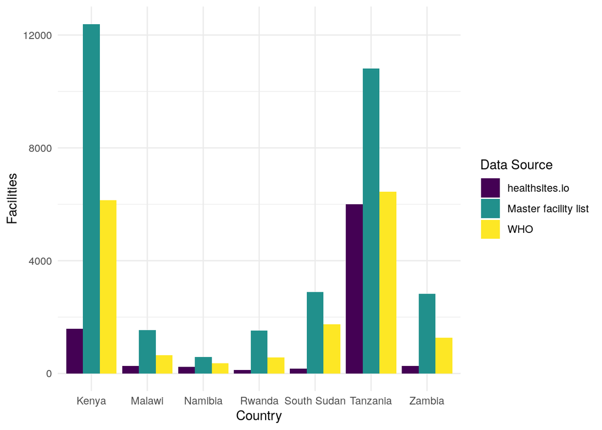

## Facility types

If we want to compare the types of facilities listed in each dataset, we first have to (manually) identify the column that contains information about facility type.

Here is the mapping:

The columns containing facility types in the WHO dataset and healthsites.io were respectively named `Facility type` and `amenity`.

- Kenya: column containing facility types in MFL = `Facility type`
  - MFL: Dispensary, Medical Clinic, Medical Center, Secondary care hospitals, Basic Health Centre, Nursing and Maternity Home, Nursing Homes, Primary care hospitals, Specialized & Tertiary Referral hospitals, Dental Clinic, MEDICAL CLINIC, VCT, Laboratory, Rehab. Center - Drug and Substance abuse, Ophthalmology, Comprehensive health Centre, NURSING HOME, Comprehensive Teaching & Tertiary Referral Hospital, Dialysis Center, Radiology Clinic, Blood Bank, Regional Blood Transfusion Centre, Pharmacy, MEDICAL CENTER, DISPENSARY, Dispensaries and clinic-out patient only, HEALTH CENTRE, Farewell Home, HOSPITALS
  - WHO: Dispensary, Health Centre, District Hospital, Sub-District Hospital, Mission Hospital, Clinic, Hospital, County Referral Hospital, Provincial General Hospital, National Referral Hospital
  - healthsites.io: pharmacy, clinic, hospital, doctors, dentist,
- Malawi: column containing facility types in MFL = `TYPE`
  - MFL: Clinic, Hospital, Dispensary, Health Centre, District Hospital, Health Post, Unclassified, Central Hospital, Private
  - WHO: Clinic, Health Centre, Community Hospital, Health Post/Dispensary, District Hospital, Mission Hospital, Rural Hospital, Central Hospital
  - healthsites.io: hospital, clinic, pharmacy, dentist
- Namibia: No column for facility types in MFL
  - WHO: Clinic, Health Centre, District Hospital, Mission Hospital, Intermediate Hospital, Central Hospital
  - healthsites.io: doctors, clinic, , pharmacy, hospital, dentist
- Rwanda: Column name for facility types in MFL = `Facility type`
  - MFL: Dispensary, Medical Clinic, Health Center, VCT center, Health Post, Laboratory/Diagnostic Center, Health Post level 2, District Pharmacy, Community-owned health facility, Provincial Hospital, Referral Hospital, District Hospital, Nursing School, Pharmaceutical Warehouse, Other facility type, facilitytype, NA, Administrative Office, Blood bank/Transfusion Center, Prison Clinic
  - WHO: Health Centre, Health Post, District Hospital, Referral Hospital, Provincial Hospital, National Referral Hospital, Secondary Health Post
  - healthsites.io: doctors, hospital, pharmacy, clinic, dentist
- South Sudan: Column name for facility types in MFL = `type`
  - MFL: Other, Primary Health Care Centre, Primary Health Care Unit, County Hospital, County Health Department, State Hospital, Specialized Hospital/Clinic, Teaching Hospital, Health Training Institutions, Ministry of Health
  - WHO: Primary Health Care Unit, Primary Health Care Centre, State Hospital, Teaching Hospital, County Hospital
  - healthsites.io: hospital, clinic, doctors, pharmacy,
- Tanzania: Column name for facility types in MFL = `Facility Type`
  - MFL: Health Labs - Level IA2 (Dispensary Laboratory), Dispensary, Clinic - Dental Clinic, Clinic - Diagnostic Centre, Clinic - Polyclinic, Health Center, Maternity Home, Clinic - Other Clinic, Clinic - Eye Clinic, Clinic - Optometry Clinic, Clinic - Specialized Polyclinic, Clinic, Hospital - Hospital at Zonal Level, Clinic - Super specialized Polyclinic, Clinic - Medical Clinic, Health Labs - Level III single purpose Health Laboratory, Hospital - Hospital at District Level, Clinic - Specialized clinic, Health Labs, Hospital - Regional Referral Hospital, Maternity and Nursing Home, Hospital - Referral Hospital at Regional Level, Clinic - General Clinic, Hospital - District Hospital, Hospital - Council Designated Hospital, Hospital - Other Hospital, Hospital - Hospital at Regional Level, Hospital - Referral Hospital at Zonal Level, Health Labs - Specimen collection point, Health Labs - Level III Multipurpose Health Laboratory, Health Labs - Level IA1 (Health centre Laboratory), Nursing Home, Hospital - Super Specialized Hospital at National Level, Clinic - Dialysis Clinic, Clinic - Physiotherapy Clinic, Hospital - Referral Hospital at National Level, NA, Health Labs - Level IIA2 (District Laboratory), Clinic - Super specialized clinic, Hospital
  - WHO: Health Centre, Dispensary, Hospital, Referral Hospital, Designated District Hospital, District Hospital, Regional Referral Hospital, National Hospital, Primary Health Care Unit, Primary Health Care Unit +, Primary Health Care Centre, Tertiary Hospital
  - healthsites.io: hospital, pharmacy, clinic, doctors, dentist, , traditional, medical_laboratory
- Zambia: Column name for facility types in MFL = `facility_type`
  - MFL: Health Post, Rural Health Centre, Hospital - Level 1, Urban Health Centre, Hospital - Level 3, NA, Hospital - Level 2, Hospital Affiliated Health Centre, Zonal Health Centre, Border Health Post
  - WHO: Health Centre, Health Post, Level 1 Hospital, Level 2 Hospital, Rural Health Centre, Clinic, Level 3 Hospital
  - healthsites.io: clinic, hospital, , pharmacy, dentist, doctors, healthcare, health_post

### Recommended facility attributes in an MFL

According to [*HIS geo-enabling: Guidance on the establishment of a common geo-registry for the simultaneous hosting, maintenance, update and sharing of master lists core to public health*](https://healthgeolab.net/DOCUMENTS/Guidance_Common_Geo-registry_Ve1.pdf) developed in 2017 by the AeHINGIS Lab and InSTEDD through funding from the Asian Development Bank, information included in an MFL are split into two domains: the *signature domain* (ellaborated on below) and the *service domain* (that includes information about services and capacity of a health facility).

1. Health facility identifier: Official unique identifier attached to the health facility
2. Health facility name: Official name of the health facility in both English and local language
3. Address: street name and number in which the health facility is located (when applicable)
4. Location in the administrative structure: Official name and code of the administrative divisions in which the health facility is located and this down to the lowest existing administrative level (a separated set of fields for each level)
5. Location in the reporting structure: Official name and code of the reporting divisions in which the health facility is located and this down to the lowest existing reporting level (when applicable and with a separated set of fields for each level)
6. Geographic coordinates: latitude and longitude of the health facility expressed in decimal degrees together with the indication of the source, method and accuracy level attached to the coordinates (a separate field for each information)
7. Health facility type: Type of the health facility based on the official classification used in the country
8. Health facility ownership or managing authority: Major (government, private) and sub classification (Ministry of Health, army, police,…) describing the entity that owns or manage the health facility. (may require for the use of separated fields)
9. Past health facility names: Official names previously attached to the health facility (may require for the use of several fields)
10. Health facility contact information: Information needed to contact the health facility through different media including but not limited to the full name and position of the health facility head as well as the phone numbers (mobile, landline) and email address (to be captured in separated fields)
11. Health facility status: To be able to capture in the common geo-registry if the health facility is active or inactive and the reason for inactivity if the later applies (to be captured in separated fields)

The guide strongly recommends that each datasource is indicated along with a time stamp for when the data was obtained. This will effectively result in three columns for each data point: the first containing the information such as the identifier, name, or coordinates; the second containing the source; and the third containing the date and time stamp of when it was obtained.

According to this document, the capturing of service domain and other information not mentioned above form part of the optional component of the MFL.

## Facility attributes

Taking a closer look at the type of attributes that are available from country MFLs and other open data sources we notice great variability in terms of how well facililties are described. The table below shows the column headers for each dataset.

| healthsite.io | WHO | Kenya MFL | Malawi MFL | Namibia MFL | Rwanda MFL | South Sudan MFL | Tanzania MFL | Zambia MFL |
| --- | --- | --- | --- | --- | --- | --- | --- | --- |
| addr_full | Admin1 | Approved | CODE | address | District | #“idGeo” | Common Name | catchment_population_cso |
| amenity | Country | Beds | COMMON NAME | alt_phone_number | District_1 | ACLED Refs | Council | catchment_population_head_count |
| beds | Facility name | Closed | DATE OPENED | catchment_population | Facility type | Alternate Names | Created At | DHIS2_UID |
| changeset_id | Facility type | Code | DISTRICT | contact_person | Facity Name | County | CTC Number | district |
| changeset_timestamp | iso3c | Constituency | LATITUDE | id | id | Deleted | Date Opened | eLMIS_ID |
| changeset_user | Lat | Cots | LONGITUDE | infrastructures | LOCATION | Ext Ref | District | facility_type |
| changeset_version | LL source | County | NAME | location_ownership | Opening Date | Extension Accessible | Facility Name | HMIS_code |
| completeness | Long | Facility type | OWNERSHIP | location_type | Ownership | Extension Operational | Facility Number | iHRIS_ID |
| contact_number | Ownership | Facility_type_category | STATUS | long_name | Province | Facility | Facility Type | latitude |
| country |  | Keph level | TYPE | name | Sector | Indicators | Generator | location |
| dispensing |  | Name | ZONE | parent_location | Subdistrict | Location | Latitude | longitude |
| electricity |  | Officialname |  | phone_number |  | Payam | Longitude | name |
| emergency |  | Open_late_night |  | point_x |  | Pilot Accessible | National Grid | operation_status |
| geometry |  | Open_public_holidays |  | point_y |  | Pilot Operational | No Electricity | ownership |
| health_amenity_type |  | Open_weekends |  | services |  | Sampled | Operating Status | province |
| healthcare |  | Open_whole_day |  |  |  | State | Other | smartcare_GUID |
| insurance |  | Operation status |  |  |  | type | Ownership |  |
| is_in_health_area |  | Owner |  |  |  |  | Region |  |
| is_in_health_zone |  | Owner type |  |  |  |  | Registration Number |  |
| iso3c |  | Public visible |  |  |  |  | Registration Status |  |
| name |  | Registration_number |  |  |  |  | Solar Panels |  |
| opening_hours |  | Regulatory body |  |  |  |  | Updated At |  |
| operational_status |  | Service_names |  |  |  |  | Village/Street |  |
| operator |  | Sub county |  |  |  |  | Ward |  |
| operator_type |  | Ward |  |  |  |  | Zone |  |
| osm_id |  |  |  |  |  |  |  |  |
| osm_type |  |  |  |  |  |  |  |  |
| source |  |  |  |  |  |  |  |  |
| speciality |  |  |  |  |  |  |  |  |
| staff_doctors |  |  |  |  |  |  |  |  |
| staff_nurses |  |  |  |  |  |  |  |  |
| url |  |  |  |  |  |  |  |  |
| uuid |  |  |  |  |  |  |  |  |
| water_source |  |  |  |  |  |  |  |  |
| wheelchair |  |  |  |  |  |  |  |  |

We can use a visual way to look at the overlap of attributes between various datasets through a wordcloud.

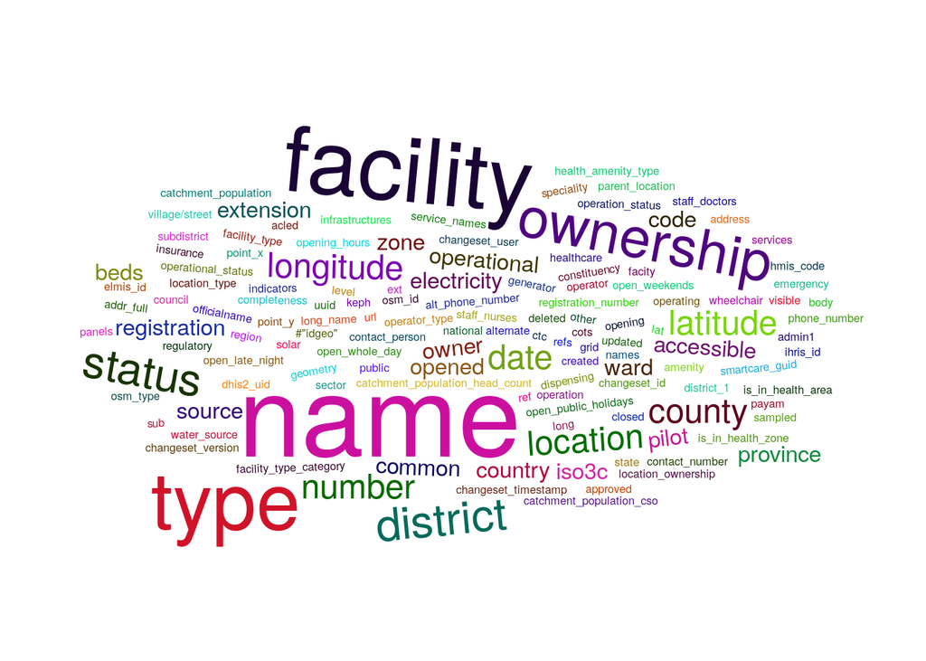